# BlackFriday

```python
# import dataset and libraries
import pandas as pd
import numpy as np
import matplotlib.pyplot as plt
import seaborn as sns
#sns.set(style="whitegrid")
from sklearn.model_selection import train_test_split
%matplotlib inline
df = pd.read_csv('BlackFriday.csv')
```

```python
# basic info about loaded datasets
print(df.info())
```

```
<class 'pandas.core.frame.DataFrame'>
RangeIndex: 537577 entries, 0 to 537576
Data columns (total 12 columns):
User_ID                       537577 non-null int64
Product_ID                    537577 non-null object
Gender                        537577 non-null object
Age                           537577 non-null object
Occupation                    537577 non-null int64
City_Category                 537577 non-null object
Stay_In_Current_City_Years    537577 non-null object
Marital_Status                537577 non-null int64
Product_Category_1            537577 non-null int64
Product_Category_2            370591 non-null float64
Product_Category_3            164278 non-null float64
Purchase                      537577 non-null int64
dtypes: float64(2), int64(5), object(5)
memory usage: 49.2+ MB
None
```

```python
# Analyze missing values
print('<Contain NaNs?>')
print(df.isnull().any())
missing_ser_percentage = (df.isnull().sum()/df.shape[0]*100).sort_values(ascending=False)
missing_ser_percentage = missing_ser_percentage[missing_ser_percentage!=0].round(2)
missing_ser_percentage.name = 'missing values %'
print('\n<NaN ratio>')
print(missing_ser_percentage)
```

```
<Contain NaNs?>
User_ID                       False
Product_ID                    False
Gender                        False
Age                           False
Occupation                    False
City_Category                 False
Stay_In_Current_City_Years    False
Marital_Status                False
Product_Category_1            False
Product_Category_2             True
Product_Category_3             True
Purchase                      False
dtype: bool

<NaN ratio>
Product_Category_3    69.44
Product_Category_2    31.06
Name: missing values %, dtype: float64
```

```python
df.head()
```

[output not shown]

```python
# replace missing values in numeric categorical fields with 0 (unused in coding those fields)
df.fillna(0,inplace=True)
# print unique values in columns
for col in df.columns:
    print('{} unique element: {}'.format(col,df[col].nunique()))
```

```
User_ID unique element: 5891
Product_ID unique element: 3623
Gender unique element: 2
Age unique element: 7
Occupation unique element: 21
City_Category unique element: 3
Stay_In_Current_City_Years unique element: 5
Marital_Status unique element: 2
Product_Category_1 unique element: 18
Product_Category_2 unique element: 18
Product_Category_3 unique element: 16
Purchase unique element: 17959
```

```
Text(0,0.5,'Count')
```

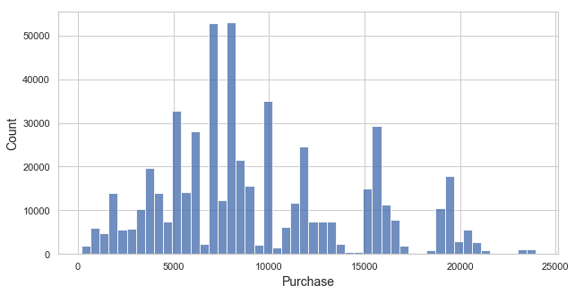

```python
# Check assumption for Linear Regression. Target Variable: Purchase should have approx. normal distribution
plt.figure(figsize=(10,5))
plt.hist(df['Purchase'],bins=50, alpha=0.8)
plt.xlabel('Purchase',fontsize=14)
plt.ylabel('Count',fontsize=14)
```

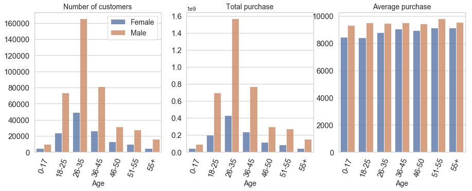

```python
# Who is likely to spend more ? Age groups, gender
# create bins for age groups
age_order = ['0-17','18-25','26-35','36-45','46-50','51-55','55+']
plt.figure(figsize=(15,5))
plt.subplot(131)
sns.countplot('Age',order=age_order,hue='Gender',data=df,alpha = 0.8)
plt.xlabel('Age',fontsize=14)
plt.ylabel('')
plt.xticks(rotation=70)
plt.title('Number of customers',fontsize=14)
plt.legend(['Female','Male'],frameon=True,fontsize=14)
plt.tick_params(labelsize=15)
plt.subplot(132)
df_Tpurchase_by_Age = df.groupby(['Age','Gender']).agg({'Purchase':np.sum}).reset_index()
sns.barplot('Age','Purchase',hue='Gender',data=df_Tpurchase_by_Age,alpha = 0.8)
plt.xlabel('Age',fontsize=14)
plt.ylabel('')
plt.xticks(rotation=70)
plt.title('Total purchase',fontsize=14)
plt.legend().set_visible(False)
plt.tick_params(labelsize=15)
plt.subplot(133)
df_Apurchase_by_Age = df.groupby(['Age','Gender']).agg({'Purchase':np.mean}).reset_index()
sns.barplot('Age','Purchase',hue='Gender',data=df_Apurchase_by_Age,alpha = 0.8)
plt.xlabel('Age',fontsize=14)
plt.ylabel('')
plt.xticks(rotation=70)
plt.title('Average purchase',fontsize=14)
plt.legend().set_visible(False)
plt.tick_params(labelsize=15)
```

Age [26-35] have most purchases in the data since they are highest in the overall population. However average purchase seems to be similar across all age groups. Points : Age may not be a strong predictor. Males spent more than Female in terms of average purchases. Gender may be a strong predictor.

```
([], <a list of 0 Text xticklabel objects>)
```

[figure not shown]

```python
# User Id and Product ID distributions : Do certain products or certain users dominate in the provided data?
plt.figure(figsize=(15,5))
plt.subplot(121)
sns.countplot('User_ID',data=df,alpha = 0.8)
plt.xlabel('User ID',fontsize=14)
plt.ylabel('')
plt.title('Total count',fontsize=14)
plt.xticks([])
plt.subplot(122)
sns.set()
sns.countplot('Product_ID',data=df,alpha = 0.8)
plt.xlabel('Product ID',fontsize=14)
plt.ylabel('')
plt.title('Total count',fontsize=14)
plt.xticks([])
```

User Id and Product Id are quite distributed in the sales data and can be helpful.

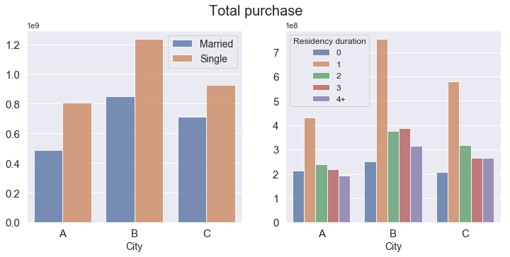

```python
# Purchase distribution by City, Marital Status, Residency Duration
df['Marital_Status_label']=np.where(df['Marital_Status'] == 0,'Single','Married')
df_Tpurchase_by_City_Marital = df.groupby(['City_Category','Marital_Status_label']).agg({'Purchase':np.sum}).reset_index()
df_Tpurchase_by_City_Stay = df.groupby(['City_Category','Stay_In_Current_City_Years']).agg({'Purchase':np.sum}).reset_index()
fig = plt.figure(figsize=(12,5))
fig.suptitle('Total purchase',fontsize=20)
plt.subplot(121)
sns.barplot('City_Category','Purchase',hue='Marital_Status_label',data=df_Tpurchase_by_City_Marital,alpha = 0.8)
plt.xlabel('City',fontsize=14)
plt.ylabel('')
plt.legend(frameon=True,fontsize=14)
plt.tick_params(labelsize=15)
plt.subplot(122)
sns.barplot('City_Category','Purchase',hue='Stay_In_Current_City_Years',data=df_Tpurchase_by_City_Stay,alpha = 0.8)
plt.xlabel('City',fontsize=14)
plt.ylabel('')
plt.legend(title='Residency duration',frameon=True,fontsize=12,loc=2)
plt.tick_params(labelsize=15)
df.drop('Marital_Status_label',axis=1,inplace=True)
```

Singles are spending more than married. Customers who lived in their city for 1 year are spending more than other groups. City B has the highest shopping spend.

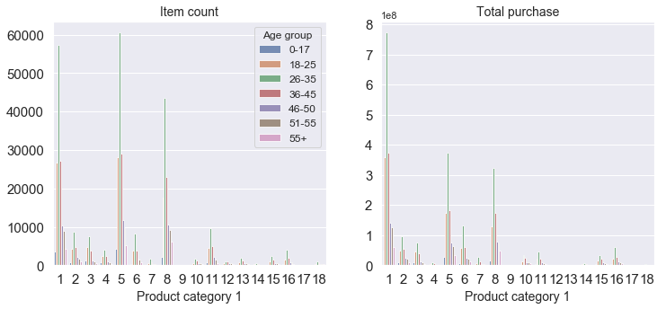

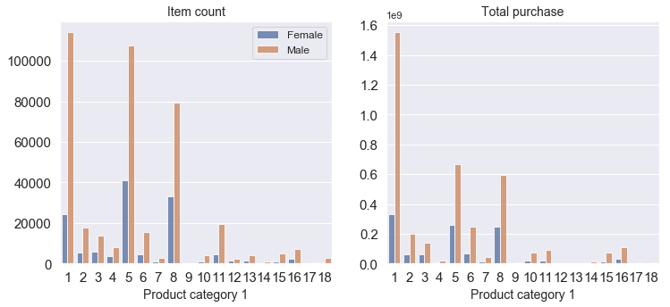

```python
df_Tpurchase_by_PC1_Age = df.groupby(['Product_Category_1','Age']).agg({'Purchase':np.sum}).reset_index()
fig = plt.figure(figsize=(12,5))
plt.subplot(121)
sns.countplot('Product_Category_1',hue='Age',data=df,alpha = 0.8,hue_order=age_order)
plt.title('Item count',fontsize=14)
plt.xlabel('Product category 1',fontsize=14)
plt.ylabel('')
plt.legend(title='Age group',frameon=True,fontsize=12)
plt.tick_params(labelsize=15)
plt.subplot(122)
sns.barplot('Product_Category_1','Purchase',hue='Age',data=df_Tpurchase_by_PC1_Age,alpha = 0.8)
plt.title('Total purchase',fontsize=14)
plt.xlabel('Product category 1',fontsize=14)
plt.ylabel('')
plt.legend().set_visible(False)
plt.tick_params(labelsize=15)

df_Tpurchase_by_PC1_Gender = df.groupby(['Product_Category_1','Gender']).agg({'Purchase':np.sum}).reset_index()
fig = plt.figure(figsize=(12,5))
plt.subplot(121)
sns.countplot('Product_Category_1',hue='Gender',data=df,alpha = 0.8)
plt.title('Item count',fontsize=14)
plt.xlabel('Product category 1',fontsize=14)
plt.ylabel('')
plt.legend(['Female','Male'],frameon=True,fontsize=12)
plt.tick_params(labelsize=15)
plt.subplot(122)
sns.barplot('Product_Category_1','Purchase',hue='Gender',data=df_Tpurchase_by_PC1_Gender,alpha = 0.8)
plt.title('Total purchase',fontsize=14)
plt.xlabel('Product category 1',fontsize=14)
plt.ylabel('')
plt.legend().set_visible(False)
plt.tick_params(labelsize=15)
```

Product_category_1 #1,5,8 sold most Product_category_1 #1 had highest revenue

Transforming categorical data into dummy variables for model fitting. Only gender and Marital Status are binary.

```python
from sklearn.preprocessing import LabelEncoder
le_U_ID = LabelEncoder()
df['User_ID'] = le_U_ID.fit_transform(df['User_ID'])
le_P_ID = LabelEncoder()
df['Product_ID'] = le_P_ID.fit_transform(df['Product_ID'])
df['Gender'] = np.where(df['Gender']=='M',1,0) # Female: 0, Male: 1
df_Age = pd.get_dummies(df.Age)
df_CC = pd.get_dummies(df.City_Category)
df_SIC = pd.get_dummies(df.Stay_In_Current_City_Years)
df_encoded = pd.concat([df,df_Age,df_CC,df_SIC],axis=1)
df_encoded.drop(['Age','City_Category','Stay_In_Current_City_Years'],axis=1,inplace=True)
```

```python
print(df_encoded.info())
```

```
<class 'pandas.core.frame.DataFrame'>
RangeIndex: 537577 entries, 0 to 537576
Data columns (total 24 columns):
User_ID               537577 non-null int64
Product_ID            537577 non-null int64
Gender                537577 non-null int32
Occupation            537577 non-null int64
Marital_Status        537577 non-null int64
Product_Category_1    537577 non-null int64
Product_Category_2    537577 non-null float64
Product_Category_3    537577 non-null float64
Purchase              537577 non-null int64
0-17                  537577 non-null uint8
18-25                 537577 non-null uint8
26-35                 537577 non-null uint8
36-45                 537577 non-null uint8
46-50                 537577 non-null uint8
51-55                 537577 non-null uint8
55+                   537577 non-null uint8
A                     537577 non-null uint8
B                     537577 non-null uint8
C                     537577 non-null uint8
0                     537577 non-null uint8
1                     537577 non-null uint8
2                     537577 non-null uint8
3                     537577 non-null uint8
4+                    537577 non-null uint8
dtypes: float64(2), int32(1), int64(6), uint8(15)
memory usage: 42.6 MB
None
```

```python
df_encoded.to_csv("df_encoded")
```

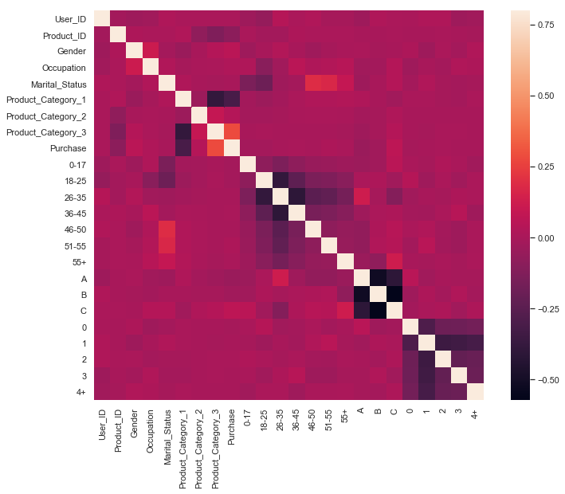

```python
corrmat = df_encoded.corr()
fig,ax = plt.subplots(figsize = (12,9))
sns.heatmap(corrmat, vmax=.8, square=True)
```

Liner Regression : Split data into an X array that contains the variables / features to train on, and a y array with the target variable

```python
df_encoded.columns
```

```
Index(['User_ID', 'Product_ID', 'Gender', 'Occupation', 'Marital_Status',
       'Product_Category_1', 'Product_Category_2', 'Product_Category_3',
       'Purchase', '0-17', '18-25', '26-35', '36-45', '46-50', '51-55', '55+',
       'A', 'B', 'C', '0', '1', '2', '3', '4+'],
      dtype='object')
```

Test and Train Split : split the dataset into a training set and a testing set. Train the model on the training set and then use the test set to evaluate the model.

```python
from sklearn.model_selection import train_test_split
#x_train, x_test, y_train, y_test = train_test_split(x, y, test_size=0.4, random_state=101)
df_train, df_test = train_test_split(df_encoded, test_size=0.4, random_state=101)
```

Create and train the model

```python
import statsmodels.formula.api as sm
model = sm.ols(formula="Purchase~Product_Category_1+Product_Category_3+Gender+Marital_Status", data=df_train)
fitted = model.fit()
fitted.summary()
```

OLS Regression Results

| Dep. Variable: | Purchase | R-squared: | 0.130 |
| --- | --- | --- | --- |
| Model: | OLS | Adj. R-squared: | 0.130 |
| Method: | Least Squares | F-statistic: | 1.205e+04 |
| Date: | Fri, 28 Dec 2018 | Prob (F-statistic): | 0.00 |
| Time: | 21:37:58 | Log-Likelihood: | -3.1812e+06 |
| No. Observations: | 322546 | AIC: | 6.362e+06 |
| Df Residuals: | 322541 | BIC: | 6.362e+06 |
| Df Model: | 4 |  |  |
| Covariance Type: | nonrobust |  |  |

|  | coef | std err | t | P>\|t\| | [0.025 | 0.975] |
| --- | --- | --- | --- | --- | --- | --- |
| Intercept | 1.003e+04 | 23.822 | 420.835 | 0.000 | 9978.397 | 1.01e+04 |
| Product_Category_1 | -314.5147 | 2.367 | -132.862 | 0.000 | -319.154 | -309.875 |
| Product_Category_3 | 150.3347 | 1.419 | 105.967 | 0.000 | 147.554 | 153.115 |
| Gender | 487.5724 | 19.036 | 25.613 | 0.000 | 450.263 | 524.882 |
| Marital_Status | 54.3583 | 16.645 | 3.266 | 0.001 | 21.735 | 86.982 |

| Omnibus: | 30603.722 | Durbin-Watson: | 1.999 |
| --- | --- | --- | --- |
| Prob(Omnibus): | 0.000 | Jarque-Bera (JB): | 40925.994 |
| Skew: | 0.799 | Prob(JB): | 0.00 |
| Kurtosis: | 3.700 | Cond. No. | 26.9 |

Warnings:  
[1] Standard Errors assume that the covariance matrix of the errors is correctly specified.

Evaluate the model

```python
# Predict on test data
from sklearn.linear_model import LinearRegression
lm = LinearRegression()
x_train=df_train[['Product_Category_1', 'Product_Category_3','Gender', 'Marital_Status']]
y_train=df_train['Purchase']
lm.fit(x_train,y_train)

x_test=df_test[['Product_Category_1', 'Product_Category_3','Gender', 'Marital_Status']]
y_test=df_test['Purchase']
```

```
Text(0,0.5,'Predicted Y')
```

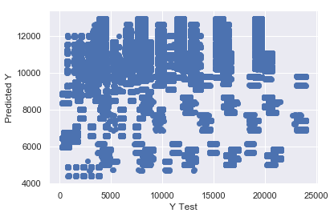

```python
# Create a scatterplot of the real test values versus the predicted values.
# Dispersion between predicted and real test values : ideal is a straight line
predictions = lm.predict(x_test)
plt.scatter(y_test,predictions)
plt.xlabel('Y Test')
plt.ylabel('Predicted Y')
```

```python
from sklearn import metrics
print('MAE:', metrics.mean_absolute_error(y_test, predictions))
print('MSE:', metrics.mean_squared_error(y_test, predictions))
print('RMSE:', np.sqrt(metrics.mean_squared_error(y_test, predictions)))
```

```
MAE: 3540.1128036467744
MSE: 21494095.74896359
RMSE: 4636.172532268789
```

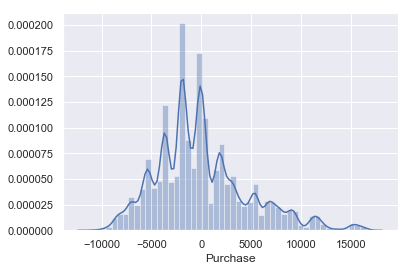

```python
# Residuals
# Plot a histogram of the residuals and make sure it looks normally distributed.
sns.distplot((y_test-predictions),bins=50);
```

```python
# coefficients
coeffecients = pd.DataFrame(lm.coef_,x_train.columns)
coeffecients.columns = ['Coeffecient']
coeffecients
```

|  | Coeffecient |
| --- | --- |
| Product_Category_1 | -314.514724 |
| Product_Category_3 | 150.334728 |
| Gender | 487.572361 |
| Marital_Status | 54.358277 |